# Quick start guide

Martin Westgate & Dax Kellie

2026-02-11

`galah` is an R interface to biodiversity data hosted by the Global Biodiversity Information Facility ([GBIF](https://www.gbif.org)) and its subsidiary node organisations. GBIF and its partner nodes collate and store observations of individual life forms using the [‘Darwin Core’](https://dwc.tdwg.org) data standard.

# Installation

To install from CRAN:

```r
install.packages("galah")
```

Or install the development version from GitHub:

```r
install.packages("remotes")
remotes::install_github("AtlasOfLivingAustralia/galah")
```

Load the package

```r
library(galah)
```

# Configuration

Begin by choosing which organisation you would like `galah` to query, and providing your registration information for that organisation.

```r
galah_config(atlas = "GBIF",
             username = "user1",
             email = "email@email.com",
             password = "my_password")
```

The full list of supported queries by organisation is as follows:

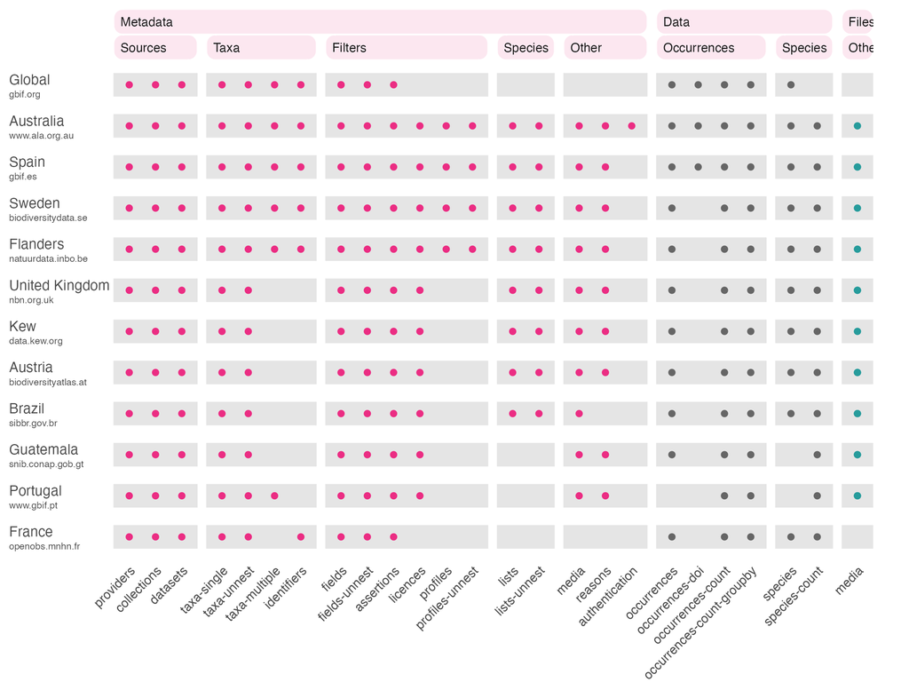

Fig 1: Organisations and APIs supported by galah

# Getting data

`galah` is a `dplyr` extension package; rather than using pipes to amend a `tibble` in your workspace, you amend a query, which is then sent to your chosen organisation. These pipes differ from traditional syntax in two ways:

- they begin with a function - usually `galah_call()` - instead of a `tibble`
- they end with one of `dplyr`’s evaluation functions, usually `collect()`

So an example query might be to find the number of records per year:

```r
galah_config(atlas = "Australia")

galah_call() |>            # open a pipe
  filter(year >= 2020) |>  # choose rows to keep
  count(year) |>           # count the number of rows
  collect()                # retrieve query from the server
```

```
## # A tibble: 7 × 2
##   year     count
##   <chr>    <int>
## 1 2024  11889930
## 2 2023  11007491
## 3 2022   9430065
## 4 2025   9142677
## 5 2021   8695248
## 6 2020   7311836
## 7 2026    309836
```

Or to find the number of categories present in a dataset, for example how many species are present:

```r
galah_call() |>
  identify("Crinia") |>   # filters by taxonomic names
  distinct(speciesID) |>  # keep only unique values
  count() |>
  collect()
```

```
## # A tibble: 1 × 1
##   count
##   <int>
## 1    17
```

You can ‘glimpse’ a data download before you run it, to check all the data you need is included:

```r
galah_call() |>
  identify("Eolophus roseicapilla") |>
  filter(year == 2010) |>
  glimpse() |>
  collect()
```

```
## Rows: 21,984
## Columns: 8
## $ taxonConceptID   <chr> "https://biodiversity.org.au/afd/taxa/9b4ad548-8bb3-486a-ab0a-905506c463ea", "https://biodiversity.org.au…
## $ eventDate        <dbl> 1.272672e+12, 1.289002e+12, 1.291014e+12
## $ scientificName   <chr> "Eolophus roseicapilla", "Eolophus roseicapilla", "Eolophus roseicapilla"
## $ decimalLatitude  <dbl> -25.98833, -37.83032, -35.41707
## $ decimalLongitude <dbl> 152.0442, 144.9812, 138.6868
## $ basisOfRecord    <chr> "HUMAN_OBSERVATION", "HUMAN_OBSERVATION", "HUMAN_OBSERVATION"
## $ dataResourceName <chr> "BirdLife Australia, Birdata", "eBird Australia", "eBird Australia"
## $ occurrenceStatus <chr> "PRESENT", "ABSENT", "ABSENT"
```

And, once satisfied that your parameters are correct, download the records themselves:

```r
galah_call() |>
  identify("Eolophus roseicapilla") |>
  filter(year == 2010) |>
  select(eventDate, decimalLatitude, species) |>
  collect()
```

```
## # A tibble: 21,984 × 3
##    eventDate decimalLatitude species
##    <dttm>              <dbl> <chr>
##  1 NA                  -36.5 Eolophus roseicapilla
##  2 NA                  -38.2 Eolophus roseicapilla
##  3 NA                  -37.0 Eolophus roseicapilla
##  4 NA                  -37.7 Eolophus roseicapilla
##  5 NA                  -35.6 Eolophus roseicapilla
##  6 NA                  -31.1 Eolophus roseicapilla
##  7 NA                  -38.2 Eolophus roseicapilla
##  8 NA                  -38.2 Eolophus roseicapilla
##  9 NA                  -38.2 Eolophus roseicapilla
## 10 NA                  -38.2 Eolophus roseicapilla
## # ℹ 21,974 more rows
```

This works because many of the functions in `dplyr` are “generic”, meaning it is possible to write extensions that apply them to new object classes. In our case, `galah_call()` creates a new object class called a `data_request` for which we have written new extensions. This means that galah will not interfere with your use of `filter()` and friends on your tibbles. Supported `dplyr` verbs that modify queries are as follows:

- `arrange.data_request()`
- `count.data_request()`
- `distinct.data_request()`
- `filter.data_request()`
- `glimpse.data_request()`
- `group_by.data_request()`
- `select.data_request()`
- `slice_head.data_request()`

Additional verbs are:

- `apply_profile()`
- `geolocate()` or `st_crop.data_request()`
- `identify.data_request()`
- `unnest()`

It is good practice to download your data in as few steps as possible, to minimize impacts on the server, and to ensure you can get a single DOI for your data. See the download data reproducibly vignette for details.

# Finding information

Building queries using `filter()` requires that you know two things:

- what **fields** (columns) are present in the dataset you are searching
- what **values** exist for those fields

Finding this information requires looking for metadata:

```r
request_metadata(type = "fields") |>
  collect()
```

```
## # A tibble: 639 × 3
##    id                  description               type
##    <chr>               <chr>                     <chr>
##  1 abcdTypeStatus      <NA>                      fields
##  2 acceptedNameUsage   Accepted name             fields
##  3 acceptedNameUsageID Accepted name             fields
##  4 accessRights        Access rights             fields
##  5 annotationsDoi      <NA>                      fields
##  6 annotationsUid      Referenced by publication fields
##  7 assertionUserId     Assertions by user        fields
##  8 assertions          Record issues             fields
##  9 assertionsCount     <NA>                      fields
## 10 associatedMedia     Associated Media          fields
## # ℹ 629 more rows
```

You can browser this tibble using `View()` or search it using `filter()`. Once you have found a field that you want to include in your query, you can find values for that field using `unnest()`:

```r
request_metadata() |>
  filter(fields == "cl22") |>
  unnest() |>
  collect()
```

```
## # A tibble: 11 × 1
##    cl22
##    <chr>
##  1 New South Wales
##  2 Victoria
##  3 Queensland
##  4 South Australia
##  5 Western Australia
##  6 Northern Territory
##  7 Tasmania
##  8 Australian Capital Territory
##  9 Macquarie Island
## 10 Coral Sea Islands
## 11 Ashmore and Cartier Islands
```

Different types of metadata are available; see `?request_metadata` for a full list.

# Wrapper functions

While `dplyr` syntax is very flexible, there are cases where it is easier to simply say the sort of data you want, rather than create a database query to implement it. For this reason, several common use cases have their own wrapper functions.

The `atlas_` family of functions act like `collect()`, but enforce a particular type of data to be returned, such as record counts:

```r
galah_call() |>
  filter(year == 2025) |>
  atlas_counts()   # note no need for a `count()` function
```

```
## # A tibble: 1 × 1
##     count
##     <int>
## 1 9142677
```

Or occurrences:

```r
galah_call() |>
  identify("Eolophus roseicapilla") |>
  filter(year == 2000,
         cl22 == "Australian Capital Territory") |>
  atlas_occurrences() |>
  print(n = 6)
```

```
## # A tibble: 2,032 × 9
##   recordID         scientificName taxonConceptID decimalLatitude decimalLongitude eventDate           basisOfRecord occurrenceStatus
##   <chr>            <chr>          <chr>                    <dbl>            <dbl> <dttm>              <chr>         <chr>
## 1 0026d29f-b6ab-4… Eolophus rose… https://biodi…           -35.4             149. 2000-08-07 00:00:00 HUMAN_OBSERV… PRESENT
## 2 0062d446-007b-4… Eolophus rose… https://biodi…           -35.3             149. 2000-03-10 00:00:00 HUMAN_OBSERV… PRESENT
## 3 00a62ee0-1e08-4… Eolophus rose… https://biodi…           -35.2             149. 2000-01-29 00:00:00 HUMAN_OBSERV… PRESENT
## 4 00ab2f4d-326f-4… Eolophus rose… https://biodi…           -35.4             149. 2000-09-25 00:00:00 HUMAN_OBSERV… PRESENT
## 5 00ae4631-ea59-4… Eolophus rose… https://biodi…           -35.3             149. 2000-02-12 00:00:00 HUMAN_OBSERV… PRESENT
## 6 00b6c8ec-e7b9-4… Eolophus rose… https://biodi…           -35.2             149. 2000-02-05 00:00:00 HUMAN_OBSERV… PRESENT
## # ℹ 2,026 more rows
## # ℹ 1 more variable: dataResourceName <chr>
```

`atlas_species()` replaces the need for `distinct()` call, while `atlas_media()` is a shortcut to a complex workflow that incorporates both data and metadata calls. Finally, metadata calls can be made more efficiently using the `show_all()` and `show_values()` functions. These take the same arguments as the `type` argument in `request_metadata()`, but use non-standard evaluation, so they don’t require quotes. They are also evaluated immediately rather than lazily:

```r
show_all(fields)
```

```
## # A tibble: 639 × 3
##    id                  description               type
##    <chr>               <chr>                     <chr>
##  1 abcdTypeStatus      <NA>                      fields
##  2 acceptedNameUsage   Accepted name             fields
##  3 acceptedNameUsageID Accepted name             fields
##  4 accessRights        Access rights             fields
##  5 annotationsDoi      <NA>                      fields
##  6 annotationsUid      Referenced by publication fields
##  7 assertionUserId     Assertions by user        fields
##  8 assertions          Record issues             fields
##  9 assertionsCount     <NA>                      fields
## 10 associatedMedia     Associated Media          fields
## # ℹ 629 more rows
```

You can check the [look up information](https://galah.ala.org.au/R/articles/look_up_information.html) vignette for further details.